# Tarea 1

# Curso: Experto en Machine Learning con Python

## PROMiDAT Iberoamericano

### Estudiante: Paola Wong Ramírez

# Tarea Numero 1

### 1. Proceda a instalar RStudio y Anaconda. Debe adjuntar un “screenshot” en el que se observe que ya estan instalados ambos en su computador.

[figure not shown]

[figure not shown]

### 2. Con la ayuda de la videoconferencia de la clase y la presentacion Conceptos Basicos en Machine Learning, que se encuentran en el Aula Virtual explique la diferencia entre Machine Learning y Minerıa de Datos.

La diferencia radica en la aplicación de ambos términos.

El aprendizaje de máquina es utilizado de manera supervisada o no supervisada en la que se estudian patrones para determinar relaciones o conexiones y así enseñarle a un modelo a crear correlaciones que lo ayudan a mejorar progresivamente, logrando crear predicciones.

La Minería de datos es completamente estadístico/matemático, se enfoca en resultados prácticos y demostrables. Básicamente, la Minería de Datos alimenta a los modelos de Machine Learning para poder obtener más hallazgos con los datos suministrados y sus respectivos modelos matemáticos aplicados solo que ahora con aprendizaje automático.

## Utilizando Python resuelva los siguientes ejercicios:

## 1.

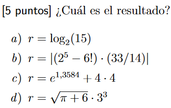

##### a) 3.9068905956085187

##### b) 1621.7142857142858

##### c) 19.88996437698103

##### d) 81.63468040279793

### Codigo empleado

```python
import math
```

```python
a = math.log2(15)
print(a)
```

```
3.9068905956085187
```

```python
b = abs((pow(2,5) - math.factorial(6)) * (33/14))
print(b)
```

```
1621.7142857142858
```

```python
c = math.exp(1.3584) + (4 * 4)
print(c)
```

```
19.88996437698103
```

```python
d = math.sqrt(math.pi + 6) * pow(3,3)
print(d)
```

```
81.63468040279793
```

## 2. Dada una cadena de texto indique si la cantidad de caracteres en la cadena es un múltiplo de 5.

## Realice una prueba para cada uno de los siguientes valores: “texto”, “cadena”, “soluciones”

```python
def multiplo_cinco(cadena):
    tamano = len(cadena)
    es_multiplo = tamano % 5 == 0
    return tamano, es_multiplo


# Los valores indicados:

valores = ["texto", "cadena", "soluciones"]


for cadena in valores:
    tamano, es_multiplo = multiplo_cinco(cadena)
    resultado = "\033[1m SI \033[0m es múltiplo" if es_multiplo else "\033[1m NO \033[0m es múltiplo"

    print(f"\033[1mEl valor '{cadena}':\033[0m tiene un tamaño de {tamano} y {resultado} de 5.""\n")
```

```
El valor 'texto': tiene un tamaño de 5 y  SI  es múltiplo de 5.

El valor 'cadena': tiene un tamaño de 6 y  NO  es múltiplo de 5.

El valor 'soluciones': tiene un tamaño de 10 y  SI  es múltiplo de 5.
```

## 3.Dados tres valores numéricos indique a que tipo de triángulo pertenece según sus lados, siendo estos Equilátero, Isósceles y Escaleno.

## Realice una prueba para cada uno de ellos

```python
def triangulo(a, b, c):
    if a == b and b == c:
        return "Equilátero"
    elif a == b or b == c or a == c:
        return "Isósceles"
    else:
        return "Escaleno"

# Probando que el codigo funciona
print("\033[1mPrueba 1. Triángulo Equilátero\033[0m (Todos sus lados iguales)")
a1 = 6
b1 = 6
c1 = 6
print(f"Los lados {a1}, {b1} y {c1} forman un triángulo \033[1m {triangulo(a1, b1, c1)} \033[0m.""\n")

print("\n""\033[1mPrueba 2. Triángulo Isósceles\033[0m (2 lados iguales)")
a2 = 6
b2 = 6
c2 = 10
print(f"Los lados {a2}, {b2} y {c2} forman un triángulo \033[1m {triangulo(a2, b2, c2)} \033[0m.""\n")

print("\n""\033[1mPrueba 3. Triángulo Escaleno\033[0m (Todos sus lados diferentes)\033[0m")
a3 = 6
b3 = 10
c3 = 9
print(f"Los lados {a3}, {b3} y {c3} forman un triángulo \033[1m {triangulo(a3, b3, c3)} \033[0m.""\n")
```

```
Prueba 1. Triángulo Equilátero (Todos sus lados iguales)
Los lados 6, 6 y 6 forman un triángulo  Equilátero .


Prueba 2. Triángulo Isósceles (2 lados iguales)
Los lados 6, 6 y 10 forman un triángulo  Isósceles .


Prueba 3. Triángulo Escaleno (Todos sus lados diferentes)
Los lados 6, 10 y 9 forman un triángulo  Escaleno .
```

## 4. Suponga que tiene las variables precio, y forma_pago, con estos datos calcule el valor a pagar en una factura de acuerdo al la foma de pago; si la forma de pago es efectivo se aplica 10 % de descuento al precio, con cheque 5 % y con tarjeta de cr ́edito no tiene descuento.

## Realice una prueba para cada uno de ellos

```python
def pago(precio, metodo_pago):
  if metodo_pago == "en efectivo":
    total_pagar = precio * 0.90

  elif metodo_pago == "con cheque":
    total_pagar = precio * 0.95

  elif metodo_pago == "Con tarjeta de credito":
    total_pagar = precio
  else:
    return "Forma de pago no válida."
  return total_pagar

#Probando que el codigo funciona
precio = 25000

metodo_pago = "en efectivo"
total_pagar = pago(precio, metodo_pago)
print(f"Precio con \033[1m10%\033[0m descuento al pagar {metodo_pago}:\033[1m {total_pagar}\033[0m""\n")

metodo_pago = "con cheque"
total_pagar = pago(precio, metodo_pago)
print(f"Precio con el \033[1m5%\033[0m descuento al pagar {metodo_pago}:\033[1m {total_pagar}\033[0m""\n")

metodo_pago = "Con tarjeta de credito"
total_pagar = pago(precio, metodo_pago)
print(f"{metodo_pago}: \033[1m No aplica descuento\033[0m. Precio:\033[1m {total_pagar}")
```

```
Precio con 10% descuento al pagar en efectivo: 22500.0

Precio con el 5% descuento al pagar con cheque: 23750.0

Con tarjeta de credito:  No aplica descuento. Precio: 25000
```

## 5. Introduzca x como una lista en python con los siguientes valores

## x = (25, 14, 78, 33, 100, 2, 154, 56, 47, 85), con ello realice lo siguiente:

## • Calcule la media, la varianza, el maximo, el mınimo y la mediana.

## • Extraiga los primeros 3 valores.

## • Obtenga la lista x invertida.

## • Ejecute el siguiente codigo e indique por que genera errores.

## > x[12]

```python
import statistics
```

```python
# Creando la lista
x = [25, 14, 78, 33, 100, 2, 154, 56, 47, 85]

# Media
media = sum(x) / len(x)

# Varianza
varianza = statistics.variance(x)

# Valor Máximo
maximo = max(x)

# Valor Mínimo
minimo = min(x)

# Mediana
mediana = statistics.median(x)

# Primeros 3 valores
tres_valores = x[:3]

# Lista invertida
x_inv = x[::-1]

print(f"• X=: \033[1m{x}\033[0m""\n")
print(f"• La media es: \033[1m{media}\033[0m""\n")
print(f"• La varianza es: \033[1m{varianza}\033[0m""\n")
print(f"• El máximo es: \033[1m{maximo}\033[0m""\n")
print(f"• El mínimo es: \033[1m{minimo}\033[0m""\n")
print(f"• La mediana es: \033[1m{mediana}\033[0m""\n")
print(f"• Los primeros 3 valores son: \033[1m{tres_valores}\033[0m""\n")
print(f"• La lista invertida es: \033[1m{x_inv}\033[0m""\n")
```

```
• X=: [25, 14, 78, 33, 100, 2, 154, 56, 47, 85]

• La media es: 59.4

• La varianza es: 2111.155555555555

• El máximo es: 154

• El mínimo es: 2

• La mediana es: 51.5

• Los primeros 3 valores son: [25, 14, 78]

• La lista invertida es: [85, 47, 56, 154, 2, 100, 33, 78, 14, 25]
```

```python
# Ejecutando el codigo del error
x[12]
```

```
---------------------------------------------------------------------------
IndexError                                Traceback (most recent call last)
~\AppData\Local\Temp\ipykernel_29304\892043093.py in <module>
      1 # Ejecutando el codigo del error
----> 2 x[12]

IndexError: list index out of range
```

### Mostrando porque x[12] da error

```python
x = [25, 14, 78, 33, 100, 2, 154, 56, 47, 85]

index = len(x)
print(f"La lista x contiene \033[1m{index}\033[0m  elementos en su índice.""\n")

try:
    x[12]
except IndexError:
    print("El índice 12 está \033[1mfuera del rango\033[0m de la lista x, por eso da error.")
```

```
La lista x contiene 10  elementos en su índice.

El índice 12 está fuera del rango de la lista x, por eso da error.
```

## 6.

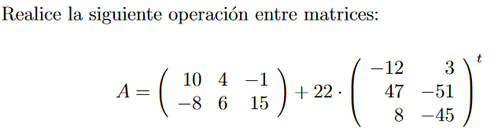

```python
import numpy as np
from numpy import matrix
```

```python
# Creando las matrices
m1 = np.array([[10, 4, -1], [-8, 6, 15]])
m2 = np.array([[-12, 3], [47, -51], [8, -45]])

matriz1=matrix(m1)
matriz2=matrix(m2)

# Matriz 2 transpuesta
t= np.transpose(m2)

#--------------------------------------------------------------
# Operación entre matrices
solucion= matriz1 + (22 * t)
print("Resultado: ""\n")
print(solucion)
print("\n")

#--------------------------------------------------------------
```

```
Resultado:

[[ -254  1038   175]
 [   58 -1116  -975]]
```

## 7. Dada la matriz cuadrada A que se presenta abajo, calcule, la suma de los elementos que conforman la diagonal. Es decir, (−11) + (−13) + 41 = 17.

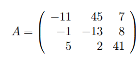

```python
matriz = np.array([[-11, 45, 7], [-1, -13, 8], [5, 2, 41]])

# Suma de los elementos que conforman la diagonal
diagonal = np.trace(matriz)

print("El resultado es: ", diagonal)
```

```
El resultado es:  17
```

## 8. Genere, sin utilizar archivos, un DataFrame con la siguiente tabla de datos:

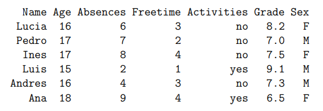

```python
import pandas as pd

# Ingresando los datos
dataframe = {'Name': ['Lucia', 'Pedro', 'Ines', 'Luis', 'Andres', 'Ana'],
        'Age': [16, 17, 17, 15, 16, 18],
        'Absences': [6,7,8,2,4,9],
        'Freetime': [3,2,4,1,3,4],
        'Activities': ["no","no","no","yes","no","yes"],
        'Grade': [8.2,7.0,7.5,9.1,7.3,6.5],
        'Sex': ['F', 'M', 'F', 'M', 'M', 'F']}

# Creando el DataFrame
df = pd.DataFrame(dataframe)

# Imprimimos el DataFrame
print(df)
```

```
     Name  Age  Absences  Freetime Activities  Grade Sex
0   Lucia   16         6         3         no    8.2   F
1   Pedro   17         7         2         no    7.0   M
2    Ines   17         8         4         no    7.5   F
3    Luis   15         2         1        yes    9.1   M
4  Andres   16         4         3         no    7.3   M
5     Ana   18         9         4        yes    6.5   F
```

## 9. Utilizando la tabla creada en el punto anterior realice lo siguiente:

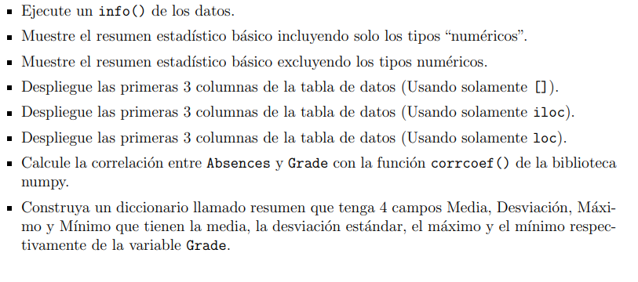

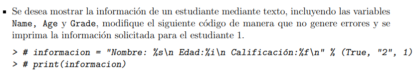

### • Muestre el resumen estadístico básico incluyendo solo los tipos “numéricos”

```python
print(df.describe(include=[np.number]))
```

```
             Age  Absences  Freetime     Grade
count   6.000000  6.000000  6.000000  6.000000
mean   16.500000  6.000000  2.833333  7.600000
std     1.048809  2.607681  1.169045  0.925203
min    15.000000  2.000000  1.000000  6.500000
25%    16.000000  4.500000  2.250000  7.075000
50%    16.500000  6.500000  3.000000  7.400000
75%    17.000000  7.750000  3.750000  8.025000
max    18.000000  9.000000  4.000000  9.100000
```

### • Muestre el resumen estadístico básico excluyendo los tipos numéricos.

```python
print(df.describe(exclude=[np.number]))
```

```
         Name Activities Sex
count       6          6   6
unique      6          2   2
top     Lucia         no   F
freq        1          4   3
```

### • Despliegue las primeras 3 columnas de la tabla de datos (Usando solamente [ ]):

```python
print(df[['Name', 'Age', 'Absences']])
```

```
     Name  Age  Absences
0   Lucia   16         6
1   Pedro   17         7
2    Ines   17         8
3    Luis   15         2
4  Andres   16         4
5     Ana   18         9
```

### • Despliegue las primeras 3 columnas de la tabla de datos (Usando solamente iloc).

```python
print(df.iloc[:, 0:3])
```

```
     Name  Age  Absences
0   Lucia   16         6
1   Pedro   17         7
2    Ines   17         8
3    Luis   15         2
4  Andres   16         4
5     Ana   18         9
```

### • Despliegue las primeras 3 columnas de la tabla de datos (Usando solamente loc).

```python
print(df.loc[:, ['Name', 'Age', 'Absences']])
```

```
     Name  Age  Absences
0   Lucia   16         6
1   Pedro   17         7
2    Ines   17         8
3    Luis   15         2
4  Andres   16         4
5     Ana   18         9
```

### • Calcule la correlación entre Absences y Grade con la función corrcoef() de la biblioteca numpy.

```python
corr = np.corrcoef(df['Absences'], df['Grade'])[0, 1]
print("La correlación entre Absences y Grade es: ", corr)
```

```
La correlación entre Absences y Grade es:  -0.787521215365597
```

### • Construya un diccionario llamado resumen que tenga 4 campos:

### Media, Desviación, Máximo y Mínimo que tienen la media, la desviación estándar, el máximo y el mínimo respectivamente de la variable Grade.

```python
resumen = {'Media': df['Grade'].mean(),
           'Desviación': df['Grade'].std(),
           'Máximo': df['Grade'].max(),
           'Mínimo': df['Grade'].min()}


print(resumen)
```

```
{'Media': 7.599999999999999, 'Desviación': 0.92520268049763, 'Máximo': 9.1, 'Mínimo': 6.5}
```

### • Se desea mostrar la información de un estudiante mediante texto, incluyendo las variables:

### Name, Age y Grade, modifique el siguiente código de manera que no genere errores y se imprima la información solicitada para el estudiante 1.

### informacion = "Nombre: %s\n Edad:%i\n Calificaci´on:%f\n" % (True, "2", 1)

### print(informacion)

```python
# Estudiante 1
estudiante1 = df.loc[0, :]

informacion = "Nombre: {}\nEdad: {}\nCalificación: {:.2f}\n".format(estudiante1['Name'], estudiante1['Age'], estudiante1['Grade'])
print(informacion)
```

```
Nombre: Lucia
Edad: 16
Calificación: 8.20
```